# Longitud y proporción de costa arenosa de República Dominicana

Clasificación U-Net y umbrales de probabilidad sobre la línea S2Coast

Análisis reproducible

2026-11-09

# 1 Objetivo y criterio de medición

Este cuaderno estima la longitud de línea costera que coincide con la clase **playa arenosa (2)** y con distintos umbrales de la probabilidad de playa. El denominador principal es la longitud total de S2Coast incluida en el archivo; se presenta también el porcentaje condicionado a los tramos con datos válidos de inferencia.

**Precaución:** la estimación se basa en puntos regularmente distribuidos a lo largo de la polilínea y ponderados por la longitud representada. No es una intersección geométrica exacta entre cada segmento de línea y cada celda ráster. La resolución del ráster, la precisión y fecha de S2Coast, y los desplazamientos entre la línea y la playa cartografiada afectan el resultado. Un píxel clasificado como playa cerca de la línea, pero no exactamente sobre ella, no se contabiliza en el análisis principal.

# 2 Preparación

```r
paquetes <- c("sf", "terra", "dplyr", "tidyr", "ggplot2", "knitr", "scales", "lwgeom")
faltantes <- setdiff(paquetes, rownames(installed.packages()))
if (length(faltantes)) {
  stop("Instala primero los paquetes: ", paste(faltantes, collapse = ", "))
}
invisible(lapply(paquetes, library, character.only = TRUE))
options(scipen = 999)
```

```r
# Ejecutar el cuaderno desde la raíz del repositorio.
# Si se ejecuta desde el directorio padre, se detecta automáticamente.
raiz <- "."
if (!dir.exists(file.path(raiz, "datos"))) {
  candidata <- "ciidi-uasd-2026-deteccion-automatizada-tramos-costeros-arenosos"
  if (dir.exists(file.path(candidata, "datos"))) raiz <- candidata
}

ruta_linea <- file.path(
  raiz, "datos", "delimitacion-ambito-linea-costa",
  "rd-s2coast-2023-mas-de-9-km2-lineas.gpkg"
)
ruta_clases <- file.path(
  raiz, "datos", "inferencia-por-sectores",
  "todos-los-sectores-clases.vrt"
)
ruta_prob <- file.path(
  raiz, "datos", "inferencia-por-sectores",
  "todos-los-sectores-clases-probabilidad.vrt"
)

rutas <- c(linea = ruta_linea, clases = ruta_clases, probabilidad = ruta_prob)
if (any(!file.exists(rutas))) {
  stop("No se encontraron estos archivos:\n",
       paste(rutas[!file.exists(rutas)], collapse = "\n"))
}

# Ajustables según el estudio
clase_playa <- 2L
umbrales <- seq(0.1, 0.9, by = 0.1)
# CRS métrico de trabajo: UTM 19N, apropiado para gran parte de RD.
# En el extremo occidental y oriental hay distorsión; para longitud
# nacional de máxima precisión puede sustituirse por un CRS equidistante
# diseñado para el área de estudio.
crs_metrico <- "EPSG:32619"

# Distancia entre puntos: NULL => mitad del tamaño de píxel menor.
# Un valor explícito (p. ej. 5) está expresado en metros.
paso_m <- NULL

# Límite de puntos por bloque para controlar la memoria.
tamano_bloque <- 30000L

# No se realiza búsqueda del píxel más cercano: extracción estricta
# en la posición de la línea S2Coast.
directorio_salida <- file.path(raiz, "resultados", "proporcion-playa")
dir.create(directorio_salida, recursive = TRUE, showWarnings = FALSE)
```

# 3 Lectura y comprobación espacial

```r
linea <- sf::st_read(ruta_linea, quiet = TRUE)
clases <- terra::rast(ruta_clases)
probabilidad <- terra::rast(ruta_prob)

if (is.na(sf::st_crs(linea))) stop("La línea no tiene CRS definido.")
if (is.na(terra::crs(clases)) || is.na(terra::crs(probabilidad))) {
  stop("Uno de los rásteres carece de CRS.")
}
if (terra::nlyr(clases) != 1L || terra::nlyr(probabilidad) != 1L) {
  stop("Se esperaba una banda por VRT. Revisa las capas disponibles.")
}

# Comprobar que la banda de probabilidad está en escala 0–1.
# No se normaliza automáticamente: una escala 0–100 requiere revisión.
linea <- sf::st_transform(linea, crs_metrico)
linea <- sf::st_make_valid(linea)
linea <- sf::st_collection_extract(linea, "LINESTRING", warn = FALSE)
linea <- sf::st_cast(linea, "LINESTRING", warn = FALSE)
linea <- linea[!sf::st_is_empty(linea), , drop = FALSE]
linea <- linea[as.numeric(sf::st_length(linea)) > 0, , drop = FALSE]
linea$id_linea <- seq_len(nrow(linea))

info <- tibble::tibble(
  fuente = c("S2Coast", "Clases", "Probabilidad"),
  crs = c(sf::st_crs(linea)$input, terra::crs(clases, proj = TRUE),
          terra::crs(probabilidad, proj = TRUE)),
  elementos = c(nrow(linea), terra::ncell(clases), terra::ncell(probabilidad))
)
knitr::kable(info, caption = "Inventario de fuentes espaciales")
```

Inventario de fuentes espaciales

| fuente | crs | elementos |
| --- | --- | --- |
| S2Coast | EPSG:32619 | 4 |
| Clases | +proj=utm +zone=19 +datum=WGS84 +units=m +no_defs | 974115449 |
| Probabilidad | +proj=utm +zone=19 +datum=WGS84 +units=m +no_defs | 974115449 |

```r
# Resolución aproximada en metros en el centro del ámbito de la línea.
centro <- sf::st_centroid(sf::st_union(sf::st_geometry(linea)))
centro_lonlat <- sf::st_transform(centro, 4326)
centro_xy <- sf::st_coordinates(centro_lonlat)[1, ]

resolucion_m <- function(r, lon, lat) {
  r_m <- terra::project(r, crs_metrico, method = "near")
  # La reproyección anterior solo se usa para estimar la resolución;
  # los valores de inferencia se extraen de los VRT originales.
  min(terra::res(r_m))
}

# Evitar reproyectar grandes rásteres completos solo para conocer
# su resolución: estimación local desde el CRS de origen.
resolucion_local <- function(r, lon, lat) {
  p <- terra::vect(data.frame(x = lon, y = lat),
                   geom = c("x", "y"), crs = "EPSG:4326")
  p_r <- terra::project(p, terra::crs(r))
  xy <- terra::crds(p_r)[1, ]
  delta <- terra::res(r)
  vecinos <- rbind(xy,
                   xy + c(delta[1], 0),
                   xy + c(0, delta[2]))
  v <- terra::vect(as.data.frame(vecinos),
                   geom = c("x", "y"), crs = terra::crs(r))
  v_m <- terra::project(v, crs_metrico)
  coords <- terra::crds(v_m)
  c(sqrt(sum((coords[2, ] - coords[1, ])^2)),
    sqrt(sum((coords[3, ] - coords[1, ])^2)))
}

res_clases <- resolucion_local(clases, centro_xy[1], centro_xy[2])
res_prob <- resolucion_local(probabilidad, centro_xy[1], centro_xy[2])
if (is.null(paso_m)) paso_m <- min(c(res_clases, res_prob)) / 2
if (!is.finite(paso_m) || paso_m <= 0) stop("Paso de muestreo inválido")

knitr::kable(
  data.frame(
    fuente = c("Clases", "Probabilidad"),
    resolucion_x_m = round(c(res_clases[1], res_prob[1]), 2),
    resolucion_y_m = round(c(res_clases[2], res_prob[2]), 2)
  ),
  caption = "Tamaño aproximado del píxel en el centro del área (m)"
)
```

Tamaño aproximado del píxel en el centro del área (m)

| fuente | resolucion_x_m | resolucion_y_m |
| --- | --- | --- |
| Clases | 10 | 10 |
| Probabilidad | 10 | 10 |

```r
cat("Paso de muestreo empleado:", round(paso_m, 2), "m\n")
```

```
## Paso de muestreo empleado: 5 m
```

# 4 Muestreo de la línea y extracción de predicciones

Se colocan puntos en el centro de intervalos de igual longitud de cada entidad lineal. Cada punto representa exactamente `longitud_de_entidad / número_de_puntos` metros; esto evita perder longitud en los extremos. Se extraen las dos capas **sin interpolación** (vecino más cercano / celda que contiene el punto).

```r
longitudes <- as.numeric(sf::st_length(linea))
n_por_linea <- pmax(1L, ceiling(longitudes / paso_m))
numero_puntos <- sum(n_por_linea)
longitud_total_km <- sum(longitudes) / 1000
cat("Longitud total de S2Coast:", round(longitud_total_km, 3), "km\n")
```

```
## Longitud total de S2Coast: 1804.736 km
```

```r
cat("Puntos de muestreo:", format(numero_puntos, big.mark = ","), "\n")
```

```
## Puntos de muestreo: 360,948
```

```r
# Generar y extraer en bloques para no mantener todos los puntos
# y geometrías en memoria simultáneamente.
extraer_linea <- function(i) {
  n <- n_por_linea[i]
  fracciones <- (seq_len(n) - 0.5) / n
  puntos <- sf::st_line_sample(sf::st_geometry(linea[i, ]),
                               sample = fracciones)
  puntos <- sf::st_cast(puntos, "POINT")
  xy <- sf::st_coordinates(puntos)[, 1:2, drop = FALSE]
  tibble::tibble(
    id_linea = i,
    x = xy[, 1],
    y = xy[, 2],
    longitud_m = rep(longitudes[i] / n, n)
  )
}

# Procesar por entidades, subdividiendo automáticamente líneas muy largas.
# Las listas de resultados se combinan al final; para líneas nacionales
# extensas puede ser conveniente aumentar paso_m si falta memoria.
resultados <- vector("list", nrow(linea))
for (i in seq_len(nrow(linea))) {
  pts <- extraer_linea(i)
  valores_clase <- rep(NA_real_, nrow(pts))
  valores_prob <- rep(NA_real_, nrow(pts))
  for (inicio in seq.int(1L, nrow(pts), by = tamano_bloque)) {
    fin <- min(inicio + tamano_bloque - 1L, nrow(pts))
    idx <- inicio:fin
    v <- terra::vect(as.data.frame(pts[idx, c("x", "y")]),
                     geom = c("x", "y"), crs = crs_metrico)
    v_cl <- terra::project(v, terra::crs(clases))
    v_pr <- terra::project(v, terra::crs(probabilidad))
    valores_clase[idx] <- terra::extract(clases, v_cl)[[2]]
    valores_prob[idx] <- terra::extract(probabilidad, v_pr)[[2]]
  }
  resultados[[i]] <- dplyr::mutate(
    pts,
    clase = valores_clase,
    prob = valores_prob
  )
  if (i %% 100 == 0L) message("Procesadas ", i, " de ", nrow(linea), " líneas")
}
muestras <- dplyr::bind_rows(resultados)
rm(resultados)

# Distinguir ausencia de datos de probabilidad cero.
muestras <- muestras |>
  dplyr::mutate(
    clase_valida = !is.na(clase) & clase %in% 1:5,
    prob_valida = !is.na(prob) & prob >= 0 & prob <= 1,
    es_playa = clase_valida & clase == clase_playa
  )

if (any(!is.na(muestras$prob) & !muestras$prob_valida)) {
  warning("Hay probabilidades fuera de [0,1]; se excluyen. Revisa la escala del VRT.")
}

saveRDS(muestras, file.path(directorio_salida, "muestras-linea.rds"))
```

# 5 Exportación de segmentos costeros a GeoPackage

Se reconstruyen **tramos lineales monoparte** a partir de la geometría original de S2Coast, conservando sus vértices intermedios. Cada punto muestreado representa un intervalo de la línea; los límites entre intervalos se sitúan a mitad de camino entre puntos de muestreo consecutivos. Los intervalos contiguos con la misma decisión se agrupan en un único tramo mediante `lwgeom::st_linesubstring()`.

Se exportan **diez GeoPackage independientes**: uno para la clasificación multiclase (clases 1–5 y categoría 0 = sin datos) y uno para cada uno de los nueve umbrales de probabilidad (playa, no playa y sin datos). Los tramos sin datos se conservan expresamente para que la suma de las longitudes represente la totalidad de S2Coast. Las geometrías son `LINESTRING`, no `MULTILINESTRING`. Para cada GeoPackage se copia también el estilo QGIS `costa_segmentada_vectorial.qml`, con el mismo nombre base que el archivo `.gpkg`, en su misma carpeta. El contenido del estilo se conserva sin modificaciones.

**Interpretación:** los límites de los tramos son aproximaciones basadas en el muestreo regular, no intersecciones exactas con los bordes de las celdas ráster. Las longitudes geométricas exportadas pueden diferir mínimamente de las sumas ponderadas por el muestreo por efectos numéricos.

```r
# Ejecutar después del bloque «muestreo». No se modifica la tabla «muestras».
directorio_gpkg <- file.path(directorio_salida, "gpkg")
dir.create(directorio_gpkg, recursive = TRUE, showWarnings = FALSE)

# Estilo QGIS de referencia, compartido por todos los GeoPackage.
ruta_qml <- file.path(directorio_salida, "costa_segmentada_vectorial.qml")
if (!file.exists(ruta_qml)) {
  stop("No se encuentra el estilo QGIS: ", ruta_qml)
}

# Los puntos de «muestras» están ordenados a lo largo de cada id_linea.
# La posición j representa el intervalo [(j-1)/n, j/n] de esa línea.
segmentar_criterio <- function(muestras, linea, criterio, umbral = NA_real_) {
  stopifnot(criterio %in% c("clases", "probabilidad"))
  indices <- split(seq_len(nrow(muestras)), muestras$id_linea)
  geometria <- vector("list", 0L)
  atributos <- vector("list", 0L)
  contador <- 0L

  for (id_txt in names(indices)) {
    idx <- indices[[id_txt]]
    id <- as.integer(id_txt)
    datos <- muestras[idx, , drop = FALSE]
    n <- nrow(datos)
    if (!n) next

    if (criterio == "clases") {
      # 0 = sin datos; 1–5 = clases originales de la U-Net.
      codigo <- ifelse(datos$clase_valida, as.integer(datos$clase), 0L)
      etiquetas <- c("Sin datos", "Urbano/artificial", "Playa arenosa",
                     "Agua", "Vegetación", "Roca/acantilado")
    } else {
      # 0 = sin datos; 1 = no playa; 2 = playa (prob >= umbral).
      codigo <- ifelse(!datos$prob_valida, 0L,
                       ifelse(datos$prob >= umbral, 2L, 1L))
      etiquetas <- c("Sin datos", "No playa", "Playa arenosa")
    }

    # Agrupar intervalos consecutivos de idéntica categoría.
    corridas <- rle(codigo)
    finales <- cumsum(corridas$lengths)
    inicios <- finales - corridas$lengths + 1L
    linea_geom <- sf::st_geometry(linea[id, ])

    for (j in seq_along(finales)) {
      desde <- (inicios[j] - 1) / n
      hasta <- finales[j] / n
      # Subcadena de la línea original; preserva los vértices interiores.
      trozo <- lwgeom::st_linesubstring(linea_geom, desde, hasta)
      if (sf::st_is_empty(trozo)[1]) next
      # st_linesubstring() de una LINESTRING devuelve una LINESTRING.
      tipo <- as.character(sf::st_geometry_type(trozo))[1]
      if (tipo != "LINESTRING") {
        stop("Geometría inesperada: ", tipo, " en id_linea ", id)
      }

      contador <- contador + 1L
      geometria[[contador]] <- trozo[[1]]
      atributos[[contador]] <- data.frame(
        id_linea = id,
        categoria = as.integer(corridas$values[j]),
        etiqueta = etiquetas[corridas$values[j] + 1L],
        umbral = if (criterio == "clases") NA_real_ else umbral,
        n_muestras = as.integer(corridas$lengths[j]),
        longitud_m_muestreo = sum(datos$longitud_m[inicios[j]:finales[j]]),
        stringsAsFactors = FALSE
      )
    }
    if (id %% 100L == 0L) {
      message(criterio, " ", umbral, ": procesadas ", id,
              " de ", nrow(linea), " líneas")
    }
  }

  if (!contador) stop("No se generaron segmentos para ", criterio)
  tabla <- dplyr::bind_rows(atributos)
  sf_segmentos <- sf::st_sf(
    tabla,
    geometry = sf::st_sfc(geometria, crs = sf::st_crs(linea))
  )
  sf_segmentos$longitud_m_geom <- as.numeric(sf::st_length(sf_segmentos))
  sf_segmentos
}

exportar_gpkg <- function(objeto, nombre_archivo) {
  destino <- file.path(directorio_gpkg, nombre_archivo)
  if (file.exists(destino)) unlink(destino)
  sf::st_write(objeto, destino, layer = "segmentos", quiet = TRUE)

  # QGIS reconoce automáticamente un archivo .qml con el mismo nombre base
  # que el GeoPackage, situado en su mismo directorio.
  destino_qml <- file.path(
    dirname(destino),
    paste0(tools::file_path_sans_ext(basename(destino)), ".qml")
  )
  copiado <- file.copy(ruta_qml, destino_qml, overwrite = TRUE)
  if (!copiado) stop("No se pudo copiar el estilo a: ", destino_qml)
  invisible(destino)
}

resumen_gpkg <- list()

# 1. Clasificación multiclase.
segmentos_clases <- segmentar_criterio(muestras, linea, "clases")
archivo_clases <- "costa_segmentada_clases.gpkg"
exportar_gpkg(segmentos_clases, archivo_clases)
resumen_gpkg[[1L]] <- data.frame(
  producto = "Clasificación U-Net",
  archivo = archivo_clases,
  n_segmentos = nrow(segmentos_clases),
  longitud_km = sum(segmentos_clases$longitud_m_geom) / 1000,
  longitud_playa_km = sum(segmentos_clases$longitud_m_geom[
    segmentos_clases$categoria == clase_playa]) / 1000
)
rm(segmentos_clases)

# 2. Nueve decisiones binarias por umbral de probabilidad.
for (k in seq_along(umbrales)) {
  u <- umbrales[k]
  segmentos_prob <- segmentar_criterio(
    muestras, linea, "probabilidad", umbral = u
  )
  nombre <- sprintf("costa_segmentada_prob_%02d.gpkg", round(100 * u))
  exportar_gpkg(segmentos_prob, nombre)
  resumen_gpkg[[k + 1L]] <- data.frame(
    producto = sprintf("Probabilidad >= %.1f", u),
    archivo = nombre,
    n_segmentos = nrow(segmentos_prob),
    longitud_km = sum(segmentos_prob$longitud_m_geom) / 1000,
    longitud_playa_km = sum(segmentos_prob$longitud_m_geom[
      segmentos_prob$categoria == 2L]) / 1000
  )
  rm(segmentos_prob)
}

tabla_exportacion <- dplyr::bind_rows(resumen_gpkg) |>
  dplyr::mutate(
    diferencia_total_m = (longitud_km - longitud_total_km) * 1000
  )
knitr::kable(
  tabla_exportacion, digits = 3,
  caption = "Archivos GeoPackage y comprobación de longitudes geométricas"
)
```

Archivos GeoPackage y comprobación de longitudes geométricas

| producto | archivo | n_segmentos | longitud_km | longitud_playa_km | diferencia_total_m |
| --- | --- | --- | --- | --- | --- |
| Clasificación U-Net | costa_segmentada_clases.gpkg | 23508 | 1804.736 | 630.244 | 0 |
| Probabilidad >= 0.1 | costa_segmentada_prob_10.gpkg | 17842 | 1804.736 | 1060.698 | 0 |
| Probabilidad >= 0.2 | costa_segmentada_prob_20.gpkg | 16900 | 1804.736 | 834.454 | 0 |
| Probabilidad >= 0.3 | costa_segmentada_prob_30.gpkg | 15437 | 1804.736 | 696.859 | 0 |
| Probabilidad >= 0.4 | costa_segmentada_prob_40.gpkg | 13792 | 1804.736 | 594.999 | 0 |
| Probabilidad >= 0.5 | costa_segmentada_prob_50.gpkg | 12038 | 1804.736 | 514.380 | 0 |
| Probabilidad >= 0.6 | costa_segmentada_prob_60.gpkg | 10555 | 1804.736 | 440.505 | 0 |
| Probabilidad >= 0.7 | costa_segmentada_prob_70.gpkg | 9180 | 1804.736 | 367.165 | 0 |
| Probabilidad >= 0.8 | costa_segmentada_prob_80.gpkg | 7603 | 1804.736 | 283.475 | 0 |
| Probabilidad >= 0.9 | costa_segmentada_prob_90.gpkg | 5129 | 1804.736 | 174.345 | 0 |

```r
write.csv(
  tabla_exportacion,
  file.path(directorio_salida, "tabla_exportacion_gpkg.csv"),
  row.names = FALSE
)

# Advertencia si hay una diferencia relevante en la longitud total.
if (any(abs(tabla_exportacion$diferencia_total_m) >
        max(1, 0.0001 * longitud_total_km * 1000))) {
  warning("Las longitudes geométricas de los GPKG difieren de la ",
          "longitud de S2Coast; revisar segmentación y geometrías.")
}
```

Los archivos se guardan en ./resultados/proporcion-playa/gpkg. En QGIS se pueden simbolizar por el campo `categoria` o por `etiqueta`. Para la clasificación, el código 2 representa playa; para cada umbral, el código 2 también representa playa, el 1 representa no playa y el 0 indica ausencia de datos.

# 6 Cobertura efectiva de los rásteres

```r
resumen_cobertura <- tibble::tibble(
  producto = c("Clasificación", "Probabilidad", "Ambos productos"),
  longitud_valida_km = c(
    sum(muestras$longitud_m[muestras$clase_valida]),
    sum(muestras$longitud_m[muestras$prob_valida]),
    sum(muestras$longitud_m[muestras$clase_valida & muestras$prob_valida])
  ) / 1000
) |>
  dplyr::mutate(
    longitud_s2coast_km = longitud_total_km,
    cobertura_pct = 100 * longitud_valida_km / longitud_s2coast_km,
    longitud_sin_datos_km = longitud_s2coast_km - longitud_valida_km
  )

knitr::kable(
  resumen_cobertura, digits = 2,
  caption = "Cobertura de inferencia sobre la longitud total de S2Coast"
)
```

Cobertura de inferencia sobre la longitud total de S2Coast

| producto | longitud_valida_km | longitud_s2coast_km | cobertura_pct | longitud_sin_datos_km |
| --- | --- | --- | --- | --- |
| Clasificación | 1788.3 | 1804.74 | 99.09 | 16.43 |
| Probabilidad | 1788.3 | 1804.74 | 99.09 | 16.43 |
| Ambos productos | 1788.3 | 1804.74 | 99.09 | 16.43 |

```r
write.csv(resumen_cobertura,
          file.path(directorio_salida, "tabla_cobertura.csv"),
          row.names = FALSE)
```

# 7 Resultados: clasificación multiclase

```r
longitud_clasificada_km <- sum(muestras$longitud_m[muestras$clase_valida]) / 1000
longitud_playa_km <- sum(muestras$longitud_m[muestras$es_playa]) / 1000

resumen_clases <- tibble::tibble(
  criterio = "U-Net: clase 2 (playa)",
  longitud_playa_km = longitud_playa_km,
  longitud_con_datos_km = longitud_clasificada_km,
  longitud_total_s2coast_km = longitud_total_km,
  porcentaje_total = 100 * longitud_playa_km / longitud_total_km,
  porcentaje_con_datos = if (longitud_clasificada_km > 0)
    100 * longitud_playa_km / longitud_clasificada_km else NA_real_
)
knitr::kable(resumen_clases, digits = 2,
             caption = "Longitud de playa obtenida de la clasificación U-Net")
```

Longitud de playa obtenida de la clasificación U-Net

| criterio | longitud_playa_km | longitud_con_datos_km | longitud_total_s2coast_km | porcentaje_total | porcentaje_con_datos |
| --- | --- | --- | --- | --- | --- |
| U-Net: clase 2 (playa) | 630.24 | 1788.3 | 1804.74 | 34.92 | 35.24 |

```r
write.csv(resumen_clases,
          file.path(directorio_salida, "tabla_clasificacion_playa.csv"),
          row.names = FALSE)

etiquetas_clase <- c("Urbano/artificial", "Playa arenosa", "Agua",
                     "Vegetación", "Roca/acantilado")
tabla_todas_clases <- muestras |>
  dplyr::filter(clase_valida) |>
  dplyr::group_by(clase) |>
  dplyr::summarise(longitud_km = sum(longitud_m) / 1000, .groups = "drop") |>
  tidyr::complete(clase = 1:5, fill = list(longitud_km = 0)) |>
  dplyr::mutate(
    nombre_clase = etiquetas_clase[as.integer(clase)],
    porcentaje_total = 100 * longitud_km / longitud_total_km,
    porcentaje_con_datos = if (longitud_clasificada_km > 0)
      100 * longitud_km / longitud_clasificada_km else NA_real_
  )
knitr::kable(tabla_todas_clases, digits = 2,
             caption = "Longitud costera por clase U-Net")
```

Longitud costera por clase U-Net

| clase | longitud_km | nombre_clase | porcentaje_total | porcentaje_con_datos |
| --- | --- | --- | --- | --- |
| 1 | 76.49 | Urbano/artificial | 4.24 | 4.28 |
| 2 | 630.24 | Playa arenosa | 34.92 | 35.24 |
| 3 | 136.12 | Agua | 7.54 | 7.61 |
| 4 | 397.86 | Vegetación | 22.05 | 22.25 |
| 5 | 547.59 | Roca/acantilado | 30.34 | 30.62 |

```r
write.csv(tabla_todas_clases,
          file.path(directorio_salida, "tabla_todas_las_clases.csv"),
          row.names = FALSE)
```

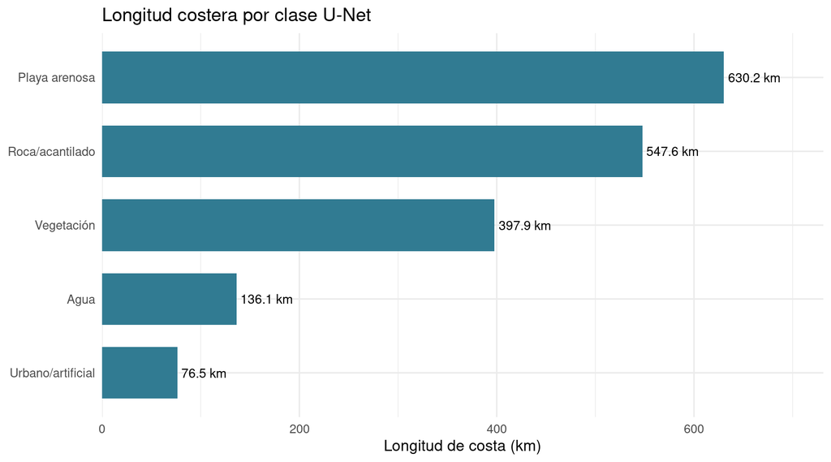

```r
g_clases <- ggplot(tabla_todas_clases,
                   aes(x = reorder(nombre_clase, longitud_km), y = longitud_km)) +
  geom_col(fill = "#317b92", width = 0.7) +
  coord_flip() +
  geom_text(aes(label = sprintf("%.1f km", longitud_km)),
            hjust = -0.08, size = 3.5) +
  scale_y_continuous(expand = expansion(mult = c(0, 0.16))) +
  labs(x = NULL, y = "Longitud de costa (km)",
       title = "Longitud costera por clase U-Net") +
  theme_minimal(base_size = 12)
print(g_clases)
```

```r
ggsave(file.path(directorio_salida, "longitud_por_clase.png"),
       g_clases, width = 9, height = 5, dpi = 300)
```

# 8 Resultados: umbrales de probabilidad

La regla para cada umbral es `probabilidad de playa >= umbral`. Esta **no necesariamente coincide** con la regla usada para producir el mapa multiclase (`argmax`), por lo que ambos productos deben presentarse por separado.

```r
longitud_prob_valida_km <- sum(muestras$longitud_m[muestras$prob_valida]) / 1000

tabla_umbrales <- dplyr::bind_rows(lapply(umbrales, function(u) {
  km <- sum(muestras$longitud_m[muestras$prob_valida &
                                 muestras$prob >= u]) / 1000
  tibble::tibble(
    umbral = u,
    longitud_playa_km = km,
    longitud_con_datos_km = longitud_prob_valida_km,
    longitud_total_s2coast_km = longitud_total_km,
    porcentaje_total = 100 * km / longitud_total_km,
    porcentaje_con_datos = if (longitud_prob_valida_km > 0)
      100 * km / longitud_prob_valida_km else NA_real_
  )
}))

knitr::kable(tabla_umbrales, digits = 2,
             caption = "Longitud y proporción de playa según umbral de probabilidad")
```

Longitud y proporción de playa según umbral de probabilidad

| umbral | longitud_playa_km | longitud_con_datos_km | longitud_total_s2coast_km | porcentaje_total | porcentaje_con_datos |
| --- | --- | --- | --- | --- | --- |
| 0.1 | 1060.70 | 1788.3 | 1804.74 | 58.77 | 59.31 |
| 0.2 | 834.45 | 1788.3 | 1804.74 | 46.24 | 46.66 |
| 0.3 | 696.86 | 1788.3 | 1804.74 | 38.61 | 38.97 |
| 0.4 | 595.00 | 1788.3 | 1804.74 | 32.97 | 33.27 |
| 0.5 | 514.38 | 1788.3 | 1804.74 | 28.50 | 28.76 |
| 0.6 | 440.50 | 1788.3 | 1804.74 | 24.41 | 24.63 |
| 0.7 | 367.16 | 1788.3 | 1804.74 | 20.34 | 20.53 |
| 0.8 | 283.47 | 1788.3 | 1804.74 | 15.71 | 15.85 |
| 0.9 | 174.34 | 1788.3 | 1804.74 | 9.66 | 9.75 |

```r
write.csv(tabla_umbrales,
          file.path(directorio_salida, "tabla_umbrales_probabilidad.csv"),
          row.names = FALSE)
```

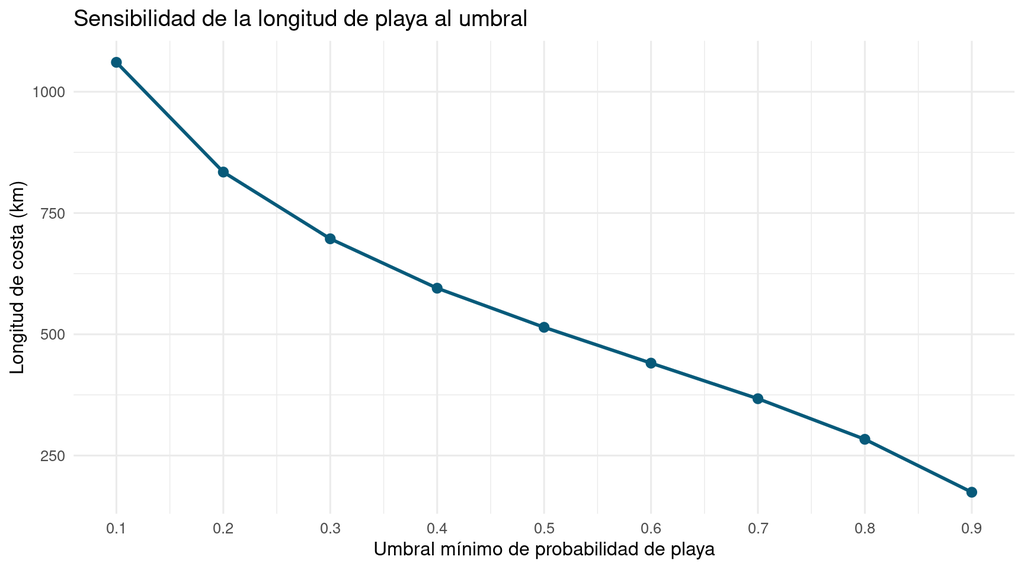

```r
g_umbrales <- ggplot(tabla_umbrales,
                     aes(x = umbral, y = longitud_playa_km)) +
  geom_line(color = "#075a7a", linewidth = 1) +
  geom_point(color = "#075a7a", size = 2.5) +
  scale_x_continuous(breaks = umbrales,
                     labels = scales::number_format(accuracy = 0.1)) +
  labs(x = "Umbral mínimo de probabilidad de playa",
       y = "Longitud de costa (km)",
       title = "Sensibilidad de la longitud de playa al umbral") +
  theme_minimal(base_size = 12)
print(g_umbrales)
```

```r
ggsave(file.path(directorio_salida, "longitud_segun_umbral.png"),
       g_umbrales, width = 9, height = 5, dpi = 300)
```

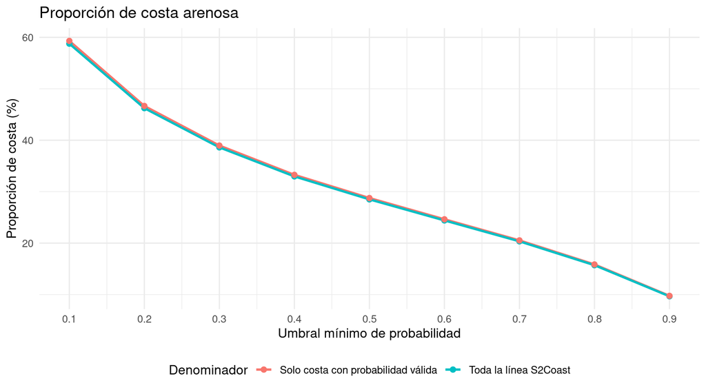

```r
tabla_larga <- tabla_umbrales |>
  dplyr::select(umbral, porcentaje_total, porcentaje_con_datos) |>
  tidyr::pivot_longer(-umbral, names_to = "denominador", values_to = "porcentaje") |>
  dplyr::mutate(denominador = dplyr::recode(
    denominador,
    porcentaje_total = "Toda la línea S2Coast",
    porcentaje_con_datos = "Solo costa con probabilidad válida"
  ))
g_prop <- ggplot(tabla_larga,
                 aes(x = umbral, y = porcentaje, color = denominador)) +
  geom_line(linewidth = 1) +
  geom_point(size = 2) +
  scale_x_continuous(breaks = umbrales) +
  labs(x = "Umbral mínimo de probabilidad", y = "Proporción de costa (%)",
       color = "Denominador", title = "Proporción de costa arenosa") +
  theme_minimal(base_size = 12) +
  theme(legend.position = "bottom")
print(g_prop)
```

```r
ggsave(file.path(directorio_salida, "proporcion_segun_umbral.png"),
       g_prop, width = 9, height = 5, dpi = 300)
```

# 9 Tabla comparativa final

```r
tabla_final <- dplyr::bind_rows(
  resumen_clases |>
    dplyr::transmute(metodo = criterio, longitud_playa_km,
                     longitud_con_datos_km, longitud_total_s2coast_km,
                     porcentaje_total, porcentaje_con_datos),
  tabla_umbrales |>
    dplyr::transmute(metodo = sprintf("Probabilidad >= %.2f", umbral),
                     longitud_playa_km, longitud_con_datos_km,
                     longitud_total_s2coast_km,
                     porcentaje_total, porcentaje_con_datos)
)
knitr::kable(tabla_final, digits = 2,
             caption = "Comparación de longitud y proporción de costa arenosa")
```

Comparación de longitud y proporción de costa arenosa

| metodo | longitud_playa_km | longitud_con_datos_km | longitud_total_s2coast_km | porcentaje_total | porcentaje_con_datos |
| --- | --- | --- | --- | --- | --- |
| U-Net: clase 2 (playa) | 630.24 | 1788.3 | 1804.74 | 34.92 | 35.24 |
| Probabilidad >= 0.10 | 1060.70 | 1788.3 | 1804.74 | 58.77 | 59.31 |
| Probabilidad >= 0.20 | 834.45 | 1788.3 | 1804.74 | 46.24 | 46.66 |
| Probabilidad >= 0.30 | 696.86 | 1788.3 | 1804.74 | 38.61 | 38.97 |
| Probabilidad >= 0.40 | 595.00 | 1788.3 | 1804.74 | 32.97 | 33.27 |
| Probabilidad >= 0.50 | 514.38 | 1788.3 | 1804.74 | 28.50 | 28.76 |
| Probabilidad >= 0.60 | 440.50 | 1788.3 | 1804.74 | 24.41 | 24.63 |
| Probabilidad >= 0.70 | 367.16 | 1788.3 | 1804.74 | 20.34 | 20.53 |
| Probabilidad >= 0.80 | 283.47 | 1788.3 | 1804.74 | 15.71 | 15.85 |
| Probabilidad >= 0.90 | 174.34 | 1788.3 | 1804.74 | 9.66 | 9.75 |

```r
write.csv(tabla_final,
          file.path(directorio_salida, "tabla_comparativa_final.csv"),
          row.names = FALSE)
```

# 10 Concordancia entre clasificación y umbral 0.5

La concordancia permite detectar si la máscara `clase == 2` coincide con `probabilidad >= 0.5`. Las discrepancias no implican necesariamente un error: una clasificación multiclase por `argmax` no exige que la clase ganadora alcance 0.5.

```r
comparables <- muestras |>
  dplyr::filter(clase_valida, prob_valida) |>
  dplyr::mutate(
    decision_clases = ifelse(clase == clase_playa, "Playa", "No playa"),
    decision_prob = ifelse(prob >= 0.5, "Playa", "No playa")
  )
tabla_concordancia <- comparables |>
  dplyr::group_by(decision_clases, decision_prob) |>
  dplyr::summarise(longitud_km = sum(longitud_m) / 1000,
                   .groups = "drop") |>
  tidyr::complete(decision_clases = c("Playa", "No playa"),
                  decision_prob = c("Playa", "No playa"),
                  fill = list(longitud_km = 0))
knitr::kable(tabla_concordancia, digits = 2,
             caption = "Concordancia de decisiones expresada en kilómetros de costa")
```

Concordancia de decisiones expresada en kilómetros de costa

| decision_clases | decision_prob | longitud_km |
| --- | --- | --- |
| No playa | No playa | 1158.06 |
| No playa | Playa | 0.00 |
| Playa | No playa | 115.86 |
| Playa | Playa | 514.38 |

```r
write.csv(tabla_concordancia,
          file.path(directorio_salida, "tabla_concordancia.csv"),
          row.names = FALSE)
```

# 11 Distribución de probabilidades sobre la costa

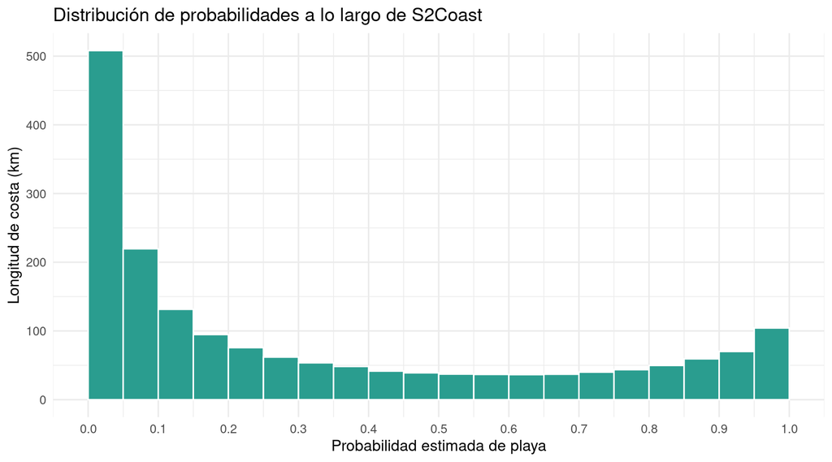

```r
g_hist <- ggplot(muestras |> dplyr::filter(prob_valida),
                 aes(x = prob, weight = longitud_m / 1000)) +
  geom_histogram(binwidth = 0.05, boundary = 0, fill = "#2a9d8f",
                 color = "white") +
  scale_x_continuous(limits = c(0, 1), breaks = seq(0, 1, 0.1)) +
  labs(x = "Probabilidad estimada de playa",
       y = "Longitud de costa (km)",
       title = "Distribución de probabilidades a lo largo de S2Coast") +
  theme_minimal(base_size = 12)
print(g_hist)
```

```r
ggsave(file.path(directorio_salida, "histograma_probabilidad_costa.png"),
       g_hist, width = 9, height = 5, dpi = 300)
```

# 12 Síntesis automática e interpretación

La línea S2Coast analizada tiene una longitud total de **1804.74 km**. La clasificación multiclase asigna **630.24 km** a playa arenosa, equivalentes al **34.92 %** de la línea completa y al **35.24 %** de la longitud con clasificación válida.

Para un umbral de probabilidad de 0.5, la longitud estimada es de **514.38 km**. Este valor debe interpretarse como longitud de S2Coast situada sobre píxeles cuya probabilidad estimada de playa alcanza o supera el umbral; **no** como una medición independiente de la anchura o superficie de la playa.

## 12.1 Limitaciones y comprobaciones pendientes

1. **Cobertura espacial:** las proporciones sobre toda S2Coast incluyen en el denominador tramos sin inferencia. Para comparar desempeño dentro del área procesada, usar también el porcentaje sobre longitud con datos válidos.
2. **Desfase espacial:** S2Coast (2023) y las predicciones (2025) pueden diferir por cambios costeros, mareas, precisión de georreferenciación y definición de la línea de costa.
3. **Contacto geométrico:** el método principal toma el valor exactamente bajo la línea. Si se busca la *longitud de frente costero asociado a una playa cercana*, será necesario un segundo análisis con banda costera y una regla explícita de vecindad (por ejemplo, presencia de playa en un radio definido hacia tierra).
4. **Resolución:** el muestreo subpíxel mejora la aproximación a la longitud, pero no añade resolución espacial a los mapas.
5. **CRS y precisión:** UTM 19N introduce distorsiones fuera de su zona central; evaluar una proyección adecuada para la extensión nacional o mediciones geodésicas para una publicación definitiva.
6. **Mosaicos VRT:** verificar solapamientos, NoData, orden de prioridad y que el VRT de probabilidad realmente almacene valores de 0 a 1.
7. **Validación:** estos resultados cuantifican predicciones del modelo, no la longitud real de playa observada. Deben contrastarse con datos independientes cuando estén disponibles.

## 12.2 Archivos generados

Las tablas CSV, las figuras PNG y las muestras extraídas se guardan en ./resultados/proporcion-playa. Los diez GeoPackage de líneas monoparte y sus diez estilos `.qml` homónimos se guardan en ./resultados/proporcion-playa/gpkg.